# A4

Neil Frazer

2020-02-07

# Introduction

This assignment is based closely on Chapter 4 of our text. This chapter reviews probability mass functions (PMFs) and probability density functions (PDFs), and introduces a concept called the highest density interval (HDI), which is a generalization of the frequentist notion of confidence interval. This chapter also tests our understanding of joint, marginal and conditional probability.

# Reminders

- If you have a chunk that crashes the knit, put `eval=FALSE` in the header and a note to me in the narrative. Your assignments should always knit—it’s the first thing I do with them.
- If you are printing numbers anywhere it may be a good idea to put the statement `options(digits=3)` in your setup chunk. Otherwise you are looking at a lot of unnecessary digits. The digits option can be changed in any other chunk, as needed.
- When explanation is needed, try to put it in the narrative rather than as comments in the code. Comments in the code should be succinct.
- Inside a LaTeX math expression you get a subscript $x_i$ by typing `$x_i$`, and a superscript $x^i$ by typing `$x^i$`.
- When you are adapting one of Kruschke’s scripts to a problem, and you see a call to `openGraph()` or `saveGraph()`, please delete it or comment it out.

# Exercise 4.0

(not in text, 10 points)  
List the technical terms you encountered in this chapter, with a ‘?’ after those you have not encountered before. Look up at least one of the terms that are new to you, and give a definition that makes sense to you.

# Solution 4.0

## Terms

- probability
- sample space ?
- long-run relative frequency ?
- distribution
- discretize
- median
- highest density interval ?

## Definitions

- sample space:
  - allowed values for a given variable
- long-run relative frequency
  - convergence point for a statsitical sample, i.e. the “true” probability of discretely-sampled test or experiment
- highest density interval
  - from the text: *“Thus, the HDI summarizes the the distribution by specifying an interval that spans most of the distribution, say 95% of it, such that every point inside the interval has a higher credibility than any point outside the interval.”* – this doesnt make much sense to me. If only requirement is that points inside have prob greater than points outside, then wouldn’t the HDI just be the infinitely narrow sliwer at the maximum prob value? or if it is forced to span a range, isn’t the range arbritrary? does 95% have a physical significance here, or just chosen to be $2\sigma$ for pedagogical purposes?

# Exercise 4.1

(A take-off on Kruschke’s Ex 4.1, p95. 15 points) This exercise has parts (a), (b) and (c).

## Ex 4.1(a)

Fill in the blanks in the following sentence. The `HairEyeColor` dataset gives the distribution of hair, eye color, and sex in (number here) _________ statistics students from the University of _________ reported by ___________ in the year ________.

**Hint:** In the console type `?datasets::HairEyeColor`, or else go to the packages tab in RStudio and click on `datasets`, then `H`, then `HairEyeColor`.

## Solution 4.1(a)

The `HairEyeColor` dataset gives the distribution of hair, eye color, and sex in **592** statistics students from the University of **Delaware** reported by **Snee** in the year **1974** (but sex data added in 1992 by Friendly).

## Ex 4.1(b)

[Mosaic plots](https://en.wikipedia.org/wiki/Mosaic_plot) are often the best way to quickly grasp the implications of data set with class `table` such as `HairEyeColor`. Consider the following figure and its caption. Does it lead you to suspect there was a lot of hair coloring being sold near universities at the time of the survey (Yes or No? Be honest). Given the time and place in which this dataset was collected, are the subjects likely to be mainly of European descent (Yes or No?). Use Google or Google Scholar to see what recent research has to say about the distribution of blond hair among males and females of European descent, and give a sentence containing a link to a not-too-sensational summary.

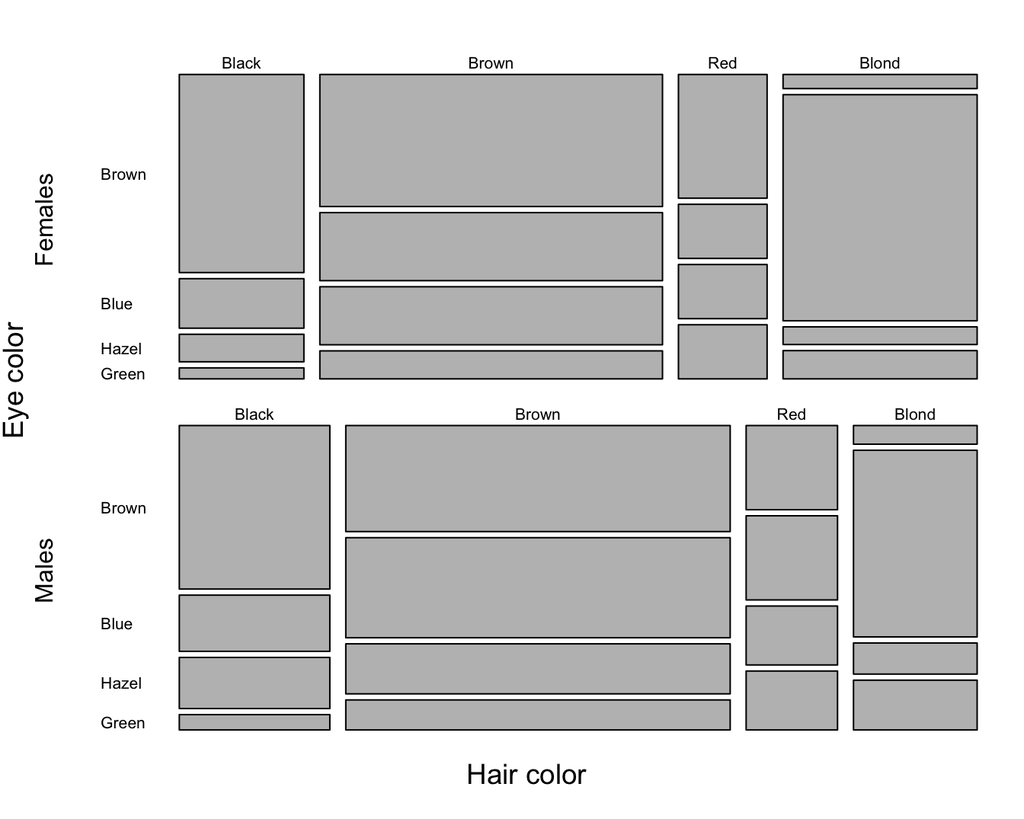

**Figure 4.1A.** Hair and eye color for female (upper panel) and male (lower panel) statistics students. Relative column widths indicate the proportions of hair color. Within each column, relative block heights indicate the proportions of eye color.

```r
par(mfrow=c(2, 1), oma=c(2,1,0,0))

## upper panel
par(mar=c(0,2,2,0))
mosaicplot(HairEyeColor[ , ,"Female"], las=1,
           main="", ylab="Females", xlab="")

## lower panel
par(mar=c(1,2,1,0))
mosaicplot(HairEyeColor[ , ,  "Male"], las=1,
           main="", ylab="Males", xlab="")

## axis labels
mtext("Hair color", side=1, line=0, outer=TRUE, cex=1.15)
mtext("Eye color" , side=2, line=0, outer=TRUE, cex=1.15)
```

## Solution 4.1(b)

Delaware in 1974? Definitely filled with European-based white people.

## Ex 4.1(c)

First an **example**: suppose you want the percentage of males that have green eyes. The following chunk, and sentence with some inline code does the job. The mosaic plots above allow a partial reality check on the answer.

```r
# dimnames(HairEyeColor)
tb <- HairEyeColor[ , , "Male"]
em <- apply(tb, MARGIN="Eye", FUN=sum)
em <- em/sum(em)*100
```

In the `HairEyeColor` dataset, 11.8% of males have green eyes.

Now the **exercise**: write a chunk, then use some inline code to complete the following sentence.

In the `HairEyeColor` dataset, only _________% of brown-haired students have green eyes, but ___________% of red-haired students have green eyes.

## Solution 4.1(c)

```r
bh = apply(HairEyeColor[ "Brown" , , ], "Eye", sum)
rh = apply(HairEyeColor[ "Red" , , ], "Eye", sum)

bh_ge = bh['Green'] / sum(bh) * 100.
rh_ge = rh['Green'] / sum(rh) * 100.
```

In the `HairEyeColor` dataset, only 10.1% of brown-haired students have green eyes, but 19.7% of red-haired students have green eyes.

# Exercise 4.2

(page 96 of text, 5 points)  
The code you need to modify for this exercise is `RunningProportion.R` which is in the folder `DBDA2Eprograms` that you downloaded for the last assignment.

# Solution 4.2

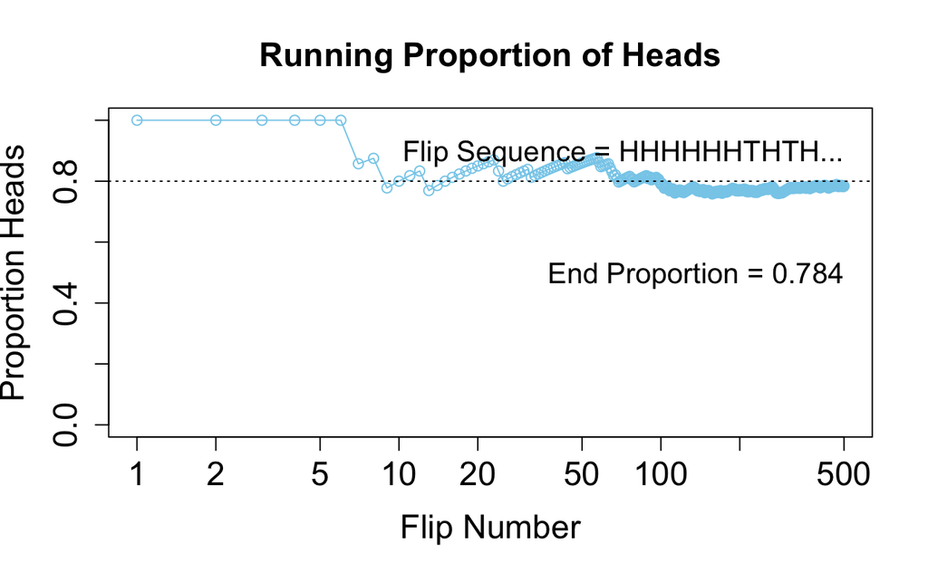

**Figure 4.2**

```r
# copied from DBDA2E
N = 500 # Specify the total number of flips, denoted N.
pHeads = 0.8 # Specify underlying probability of heads.
# Flip a coin N times and compute the running proportion of heads at each flip.
# Generate a random sample of N flips (heads=1, tails=0):
flipSequence = sample( x=c(0,1), prob=c(1-pHeads,pHeads), size=N, replace=TRUE )
# Compute the running proportion of heads:
r = cumsum( flipSequence ) # Cumulative sum: Number of heads at each step.
n = 1:N                    # Number of flips at each step.
runProp = r / n            # Component by component division.
# Graph the running proportion:
plot( n , runProp , type="o" , log="x" , col="skyblue" ,
      xlim=c(1,N) , ylim=c(0.0,1.0) , cex.axis=1.5 ,
      xlab="Flip Number" , ylab="Proportion Heads" , cex.lab=1.5 ,
      main="Running Proportion of Heads" , cex.main=1.5 )
# Plot a dotted horizontal reference line:
abline( h=pHeads , lty="dotted" )
# Display the beginning of the flip sequence:
flipLetters = paste( c("T","H")[flipSequence[1:10]+1] , collapse="" )
displayString = paste0( "Flip Sequence = " , flipLetters , "..." )
text( N , .9 , displayString , adj=c(1,0.5) , cex=1.3 )
# Display the relative frequency at the end of the sequence.
###
# modified location of End Proportion txt so doesnt overlap with line
###
text( N , .5 , paste("End Proportion =",runProp[N]) , adj=c(1,0.5) , cex=1.3 )
```

# Exercise 4.3

(This is Ex 4.3 on page 96 of our text, 5 points)

# Solution 4.3

This seems like a perfect usage for Python’s classes, but I couldn’t figure out object orientation in r in the 5 min I spent poking around so I left everything as an array of lists. Poor performance, but gets the job done.

Here’s the simple analytical solution: 10 is one of 6 options, so $p(10)=1/6$  
10 and Jack are two of 6 possible options, so just double the chances since chances per suit are equal for both options. $p(10 || J) = p(10)+p(J) = 1/6+1/6 = 1/3$ (here use $||$ as “or” symbol, not conjuction)

```r
#  now, this could be done analytically pretty easily, but
# I want to try some things out in r so
# this is my caveat that I know I'm not doing this the most
# efficient way

Ncard = 48 # number of cards in pinocle deck
suits = c('heart', 'diamond', 'club', 'spade')
values = c('9', '10', 'J', 'Q', 'K', 'A')
Ncopy = 2

cards = list()
counter = 0
for (suit in suits){
  for (value in values){
    for (i in range(0, Ncopy)){
      # neither option seems to work
      cards = append(cards, list("s"=suit, "v"=value))
#      cards[counter] = list("s"=suit, "v"=value)
#      counter = counter + 1
    }
  }
}

#not sure why this returns null, must be missing some nuance of nested lists?
print(cards[20]$s)
```

# Exercise 4.4

(This is Ex 4.4 on page 96 of our text, 15 points) For part (a), in which you make a chunk out of Kruschke’s `IntegralOfDensity.R`, be sure to comment out the calls to his `openGraph()` and `saveGraph()`.

# Solution 4.4(a)

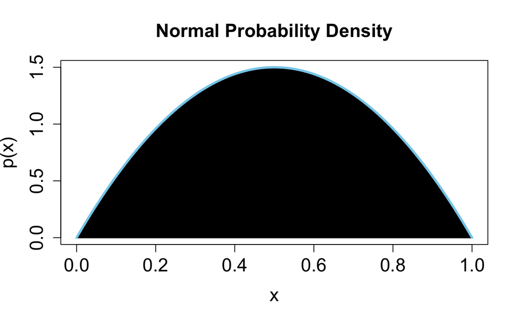

**Figure 4.4**

```r
# copied from DBDA2E
###
# Graph of normal probability density function, with comb of intervals.
xlow  = 0 # Specify low end of x-axis.
xhigh = 1 # Specify high end of x-axis.
dx = 1/10000               # Specify interval width on x-axis
# Specify comb of points along the x axis:
x = seq( from = xlow , to = xhigh , by = dx )
# Compute y values, i.e., probability density at each value of x:
y = 6*x*(1.-x)
# Plot the function. "plot" draws the intervals. "lines" draws the bell curve.
plot( x , y , type="h" , lwd=1 , cex.axis=1.5
    , xlab="x" , ylab="p(x)" , cex.lab=1.5 ,
    , main="Normal Probability Density" , cex.main=1.5 )
lines( x , y , lwd=3 ,  col="skyblue" )
```

```r
# Approximate the integral as the sum of width * height for each interval.
area = sum( dx * y )
# Display info in the graph.
```

## Solution 4.4(b)

Question says to compute the integral of the function but then points to an expectation value, but just drop the $x$ from Eq. 4.7 and all works out.

$$I = \int_{0}^1 p(x) \; dx = 6\int_{0}^1 x(1-x)\;dx = 6(\int_0^1 x\; dx - \int_0^1 x^2\;dx ) = 6( 0.5x^2 - 1/3x^3) |_0^1 = 3(1)^2 - 2(1)^3 = 3-2 = 1$$

# Exercise 4.5

(This is Ex 4.5 from page 96 of our text, 10 points)

## Solution 4.5(a)

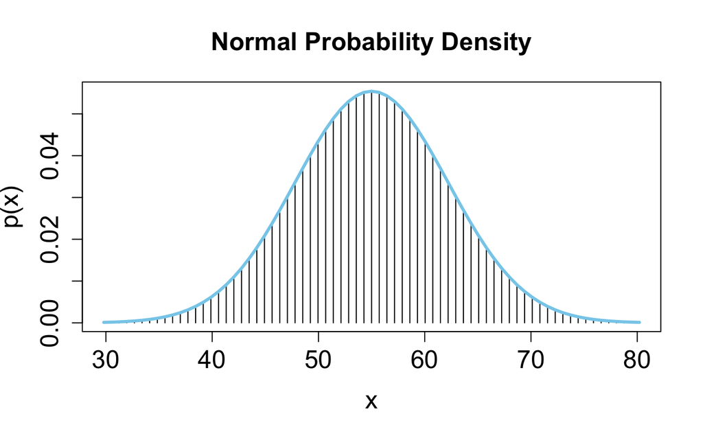

**Figure 4.5a**

```r
# Graph of normal probability density function, with comb of intervals.
meanval = 55.0               # Specify mean of distribution.
sdval = 7.2              # Specify standard deviation of distribution.
xlow  = meanval - 3.5*sdval # Specify low end of x-axis.
xhigh = meanval + 3.5*sdval # Specify high end of x-axis.
dx = sdval/10               # Specify interval width on x-axis
# Specify comb of points along the x axis:
x = seq( from = xlow , to = xhigh , by = dx )
# Compute y values, i.e., probability density at each value of x:
y = ( 1/(sdval*sqrt(2*pi)) ) * exp( -.5 * ((x-meanval)/sdval)^2 )
# Plot the function. "plot" draws the intervals. "lines" draws the bell curve.

plot( x , y , type="h" , lwd=1 , cex.axis=1.5
    , xlab="x" , ylab="p(x)" , cex.lab=1.5 ,
    , main="Normal Probability Density" , cex.main=1.5 )
lines( x , y , lwd=3 ,  col="skyblue" )
```

Couldn’t get the following code to work for some reason…

```r
# Approximate the integral as the sum of width * height for each interval.
area = sum( dx * y )
bounded_2sigma = 0.0
x0 = meanval - 2.0*sdval
x1 = meanval + 2.0*sdval

# loop through x values and store the corresponding y value if x[i] within +/- 2 sigma
# not sure why this didn't work
# get "arg is of length zero" error ...
for (i in 0:length(x)) {
  print(i)
  print(x[i])
  if ( (x[i] >= x0) & (x[i] <= x1) ){
    bounded_2sigma = bounded_2sigma + y[i]
  }
}
frac = bounded_2sigma / area
print(frac)
```

## Solution 4.5(b)

simple proportions here. We know the typical “z-score” formula $z = (x-\mu)/\sigma$ for normal dist. params $\mu, \sigma$. For 66% encapsulation, this is *almost* $z=1$, but we’ll use the more exact $z\approx0.97$ for our calculations. Now we can solve for the stddev $\sigma$ from the z-score equation:
$$z = \frac{x-\mu}{\sigma} \rightarrow \sigma = \frac{x - \mu}{z} = \frac{177 - 162}{0.97} = \frac{15}{0.97} \approx 15.5$$

Finding $\mu$ is trivial, we are given the central value of $\mu=162~$cm.

# Exercise 4.6

(This is Ex 4.6 on page 97 of our text, 10 points)  
This exercise tests our understanding of joint, conditional and marginal probability. We need to remember the **product rule**: $\Pr(F,G)=\Pr(F|G)\Pr(G)$. We also need the **marginalization rule** for a probability mass function: $\Pr(F)=\sum_G \Pr(F,G)$.

**Hints:** We are given $\Pr(G)$ in the statement of the problem. We are given $\Pr(F|G)$ in a table, with $F$ as the column index and $G$ as the row index. Proceed as follows: (1) use the product rule to make the table $\Pr(F,G)$; (2) use marginalization to make $\Pr(F)$; (3) check independence. If $\Pr(F,G)\ne\Pr(F)\Pr(G)$ for any choice of $F$ and $G$ then food and grade are not independent. The choices F = ice cream and G = first grade worked for me.

# Solution 4.6

Joint prob is just $P(G)\times P(F|G)$, so we can write the join P table:

| Grade | IC | Fruit | French Fries |
| --- | --- | --- | --- |
| 1st | 0.06 | 0.12 | 0.02 |
| 6th | 0.12 | 0.06 | 0.02 |
| 11th | 0.18 | 0.06 | 0.36 |
| $P(F)$ | 0.36 | 0.24 | 0.40 |

Now to check against $P(G)\times P(F)$: $P(G) = (0.2, 0.2, 0.6)$ and $P(F) = (0.36, 0.24, 0.40)$, sthe values for $P(F)\times P(G)$ are

| $P(F),P(G)$ | 0.36 | 0.24 | 0.40 |
| --- | --- | --- | --- |
| 0.2 | 0.072 | 0.048 | 0.08 |
| 0.2 | 0.072 | 0.048 | 0.08 |
| 0.6 | 0.216 | 0.144 | 0.24 |

And we see the values from the first tabl;e are not equal to the values from the second table, which would be the case if the variables were independent. Tried to do this with a fancy data frame but still getting used to $r$.

# Et cetera department

If you have a question, or a suggestion for class, tell me here.

- Going over this last problem and using joint probabilities would be useful, either in-class or I can stop by during office hours. Joint probabilities are really interesting to me, as they encode the most information about a sample, but I struggle with understanding when and where they can and cannot be implemented/utilized.